# Canadian_Cannabis _Index _Summary

```python
from IPython.display import HTML

HTML('''<script>
code_show=true;
function code_toggle() {
 if (code_show){
 $('div.input').hide();
 } else {
 $('div.input').show();
 }
 code_show = !code_show
}
$( document ).ready(code_toggle);
</script>
The raw code for this IPython notebook is by default hidden for easier reading.
To toggle on/off the raw code, click <a href="javascript:code_toggle()">here</a>.''')
```

The raw code for this IPython notebook is by default hidden for easier reading. To toggle on/off the raw code, click here.

```python
import numpy as np
import pandas as pd

import scipy
# import statsmodels.api as sm


from sklearn import mixture as mix
from sklearn.preprocessing import StandardScaler
from sklearn.svm import SVC


import bt
import ffn
import jhtalib as jhta
import datetime

# import matplotlib as plt
import seaborn as sns
sns.set()


import datetime
import matplotlib.pyplot as plt


#If want Futures data call Quandl


# # Dates
start = datetime.datetime(2005, 1, 1)
end = datetime.datetime(2019, 1, 27)
```

```python
import fix_yahoo_finance as fyf
from pandas_datareader import data as pdr
fyf.pdr_override()
pd.core.common.is_list_like = pd.api.types.is_list_like
import pandas_datareader as pdr
# %pylab
# params = {'legend.fontsize': 'x-large',
#           'figure.figsize': (15, 5),
#          'axes.labelsize': 'x-large',
#          'axes.titlesize':'x-large',
#          'xtick.labelsize':'x-large',
#          'ytick.labelsize':'x-large'}
# pylab.rcParams.update(params)

%matplotlib inline
```

```python
# stocks = ['WEED.TO','ACB.TO','TLRY',
#          'CRON.TO', 'HEXO.TO', 'TRST.TO',
#          'OGI.V', 'TGOD.TO', 'RIV.V', 'TER.CN',
#          'XLY.V', 'FIRE.V', 'EMH.V',
#          'N.V', 'VIVO.V', 'WAYL.CN',
#          'HIP.V', 'APHA.TO', 'SNN.CN', 'ISOL.CN']
```

```python
# Maijuana_Index = pdr.get_data_yahoo(stocks,start= start)
# #
```

```python
# (Maijuana_Index['Adj Close']['2017':]).plot(figsize=(15,9), title='Canadain Cannibis Index Components')
```

```python
# Maijuana_Index = Maijuana_Index['Adj Close']

# Maijuana_Index = ffn.rebase(Maijuana_Index)
```

```python
# Real_Es_Sector = ['IIPR', 'MJNE', 'PRRE',
#                   'GRWC', 'ZDPY', 'TURV',
#                   'AGTK', 'DPWW', 'CGRA',
#                   'DPWW', 'FUTL', 'FTPM']

# Real_Es_Sector = ['PRRE']
```

```python
# list(dict.values(client.get_ticker_metadata(('HYYDF'))))
```

```python
# # def get_names(list):
# try:
#     for i in range(len(Real_Es_Sector)):
# #         df = pd.DataFrame(len(Real_Es_Sector))

#         x  = print(list(dict.values(client.get_ticker_metadata((Real_Es_Sector[i]))))[5])
# except:
#     pass

# #     print(list(dict.values(client.get_ticker_metadata((Real_Es_Sector[i]))))[5])
```

```python
# Canada_Index_Names = ['Canaopy Growth Corporation', 'Aurora Canabis Inc.',
#                'Tilray Inc.', 'Cronos Group Inc.', 'Aphria Inc', 'HEXO Corp.'
#                'CannTrust Holdings Inc.', 'OrganiGram Holdings Inc',
#                 'The Green Organic Dutchman','Canopy Rivers Inc.',
#                 'TerrAscend Corp.', 'Auxly Cannabis Group Inc.',
#                 'The Supreme Cannabis Company Inc.','Emerald Health Therapeutics Inc.',
#                 'Namaste Technologies Inc.', 'Vivo Cannabis Inc.','Newstrike Brands Ltd',
#                 'Wayland Group','Sunniva Inc - Ordinary Shares',
#                 'Isodiol International Inc.']
```

```python
# list(dict.values(client.get_ticker_metadata(('CGRA'))))
```

```python
# %%html
# <iframe src="https://www.bloomberg.com/quote/HEXO:CN" width="1400" height="1300"></iframe>
```

# Based On the Canadian Marijuana Index these are the primary players in the Canadian Market.

###### source : http://marijuanaindex.com/stock-quotes/canadian-marijuana-index/

###### source : https://www.bloomberg.com/quote/WEED:CN

## 1. Canopy Growth Corporation : ticker WEED

### - Mkt cap $13,126,000,000 CAD as of January 2019

##### Canopy Growth Corporation, through its subsidiaries, is a producer of medical marijuana. The Company's group of brands represents distinct voices and market positions designed to appeal to an array of customers, doctors and strategic industry partners.

Bloomberg Description: https://www.bloomberg.com/quote/WEED:CN

CEO: Bruce Linton https://www.linkedin.com/in/bruce-linton-152137/

CFO: Tim Saunders https://www.linkedin.com/in/tsaunders/

```python
WEED = pdr.get_data_yahoo('WEED.TO',start= start)
```

# Canopy Growth Corporation

### Price Action

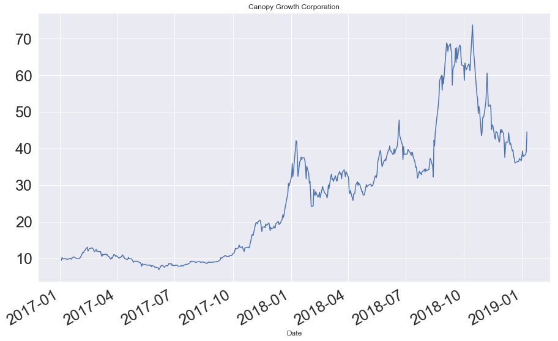

```python
WEED['Adj Close']['2017':].plot(figsize=(15,9), title='Canopy Growth Corporation', fontsize=25)
```

## 2. Aurora Cannabis Inc. : ticker ACB.TO

### - Mkt cap $6,970,000,000 CAD as of January 2019

##### Overview

source :https://www.linkedin.com/company/aurora-cannabis-inc-/about/

Aurora Cannabis Inc. is a world-renowned integrated cannabis company with an industry-leading reputation for continuously elevating and setting the global cannabis industry standard.

Through our wholly owned subsidiaries, strategic investments, and global partnerships, Aurora provides a wide range of premium quality cannabis and hemp products and services, develops innovative technologies, promotes cannabis consumer health and wellness, and delivers an exceptional customer experience across all its brands.

Aurora’s operations span multiple continents and focuses on both the medical and recreational cannabis production and sales, patient education and clinic counselling services, home hydroponic cultivation, extraction technologies and delivery systems, and hemp-based food health products.

We operate around the globe pursuing new and emerging cannabis markets where possible through our owned network of import, export and wholesale distributors, and our e-commerce and mobile applications.

Bloomberg Description: https://www.bloomberg.com/quote/ACB:CN

CEO: Terry Booth https://www.linkedin.com/in/terry-booth-681806131/

CFO: Glen Ibbott https://www.linkedin.com/in/glenibbott/

```python
ACB = pdr.get_data_yahoo('ACB.TO',start= start)
```

# Aurora Cannabis Inc

### Price Action

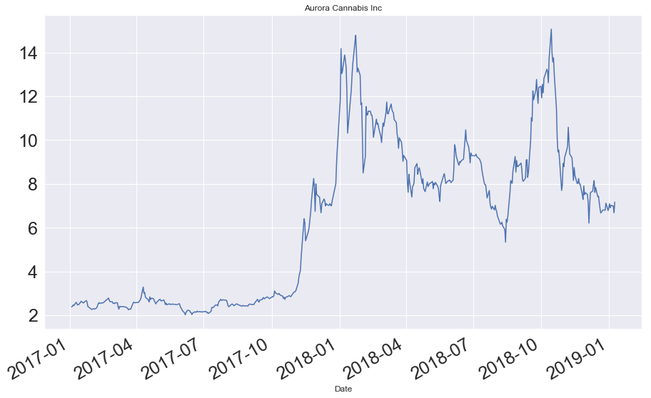

```python
ACB['Adj Close']['2017':].plot(figsize=(15,9), title='Aurora Cannabis Inc', fontsize=25)
```

## 3. Tilray Inc. : ticker TLRY

### - Mkt cap $6,699,000,000 CAD as of January 2019

##### Overview

source :https://www.linkedin.com/company/tilray/about/

Tilray is a global leader in medical cannabis research and production dedicated to providing safe, consistent and reliable therapy to patients. We are the only GMP certified medical cannabis producer currently supplying products to thousands of patients, physicians, pharmacies, hospitals, governments and researchers in Australia, Canada, the European Union and the Americas.

Bloomberg Description: https://www.bloomberg.com/quote/TLRY:US

CEO: Brendan Kennedy https://www.linkedin.com/in/kennedybrendan/

CFO: Mark Castaneda https://www.linkedin.com/in/mark-castaneda-ba8315/

```python
TLRY = pdr.get_data_yahoo('TLRY',start= start)
```

# Tilray Inc

### Price Action

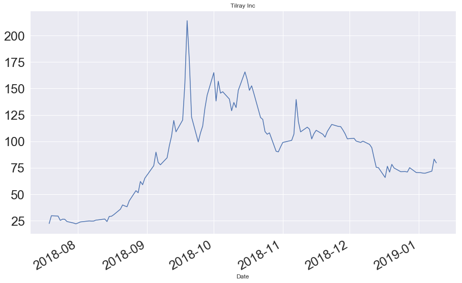

```python
TLRY['Adj Close']['2017':].plot(figsize=(15,9), title='Tilray Inc', fontsize=25)
```

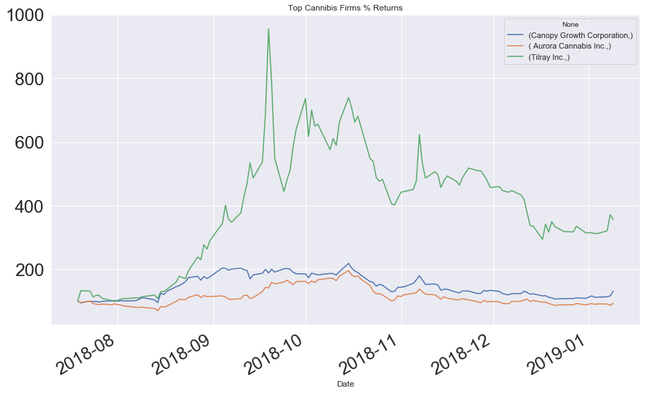

```python
top_three = pd.DataFrame(bt.merge(WEED['Adj Close'], ACB['Adj Close'], TLRY['Adj Close']))

top_three.columns = [['Canopy Growth Corporation', ' Aurora Cannabis Inc.', 'Tilray Inc.']]

top_three = top_three.dropna()
ffn.rebase(top_three).plot(figsize=(15,9), title='Top Cannibis Firms % Returns', fontsize=25)
```

## 4. Cronos Group Inc. : ticker CRON.TO

### - Mkt cap $2,950,000,000 CAD as of January 2019

##### Overview

source :https://www.linkedin.com/company/cronos-group-mjn-/about/

Cronos Group is a globally diversified and vertically integrated cannabis company with a presence across four continents. The Company operates two wholly-owned Canadian Licensed Producers regulated under Health Canada’s Access to Cannabis for Medical Purposes Regulations: Peace Naturals Project Inc. (Ontario), which was the first non-incumbent medical cannabis license granted by Health Canada, and Original BC Ltd. (British Columbia), which is based in the Okanagan Valley. The Company has multiple international production and distribution platforms: Cronos Israel and Cronos Australia. Through an exclusive distribution agreement, Cronos also has access to over 12,000 pharmacies in Germany as the Company focuses on building an international iconic brand portfolio and developing disruptive intellectual property.

Bloomberg Description: https://www.bloomberg.com/quote/CRON:CN

CEO: Michael Gorenstein https://www.linkedin.com/in/michaelgorenstein/

CFO: Nauman Siddiqui https://www.linkedin.com/in/nauman-siddiqui-cpa-cma-bba-b068aa32/

```python
CRON = pdr.get_data_yahoo('CRON.TO',start= start)
```

# Cronos Group Inc

### Price Action

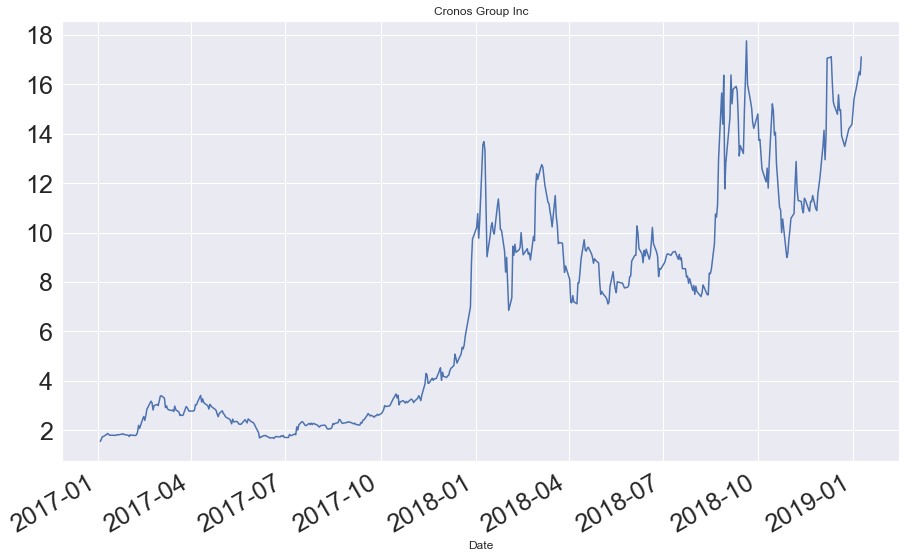

```python
CRON['Adj Close']['2017':].plot(figsize=(15,9), title='Cronos Group Inc', fontsize=25)
```

## 5. HEXO Corp : ticker HEXO.TO

### - Mkt cap $1,260,000,000 CAD as of January 2019

##### Overview

source : https://www.linkedin.com/company/hexo-corp/about/

HEXO Corp is one of Canada's lowest cost producers of easy-to-use and easy-to-understand products to serve the Canadian medical and adult-use cannabis markets. HEXO Corp's brands include Hydropothecary, an award-winning medical cannabis brand and HEXO, for the adult-use market.

Bloomberg Description: https://www.bloomberg.com/quote/HEXO:CN

CEO: Adam Miron https://www.linkedin.com/in/adammiron/

CFO: Ed Chaplin https://www.linkedin.com/in/echaplin/

```python
HEXO = pdr.get_data_yahoo('HEXO.TO',start= start)
```

# HEXO Inc

### Price Action

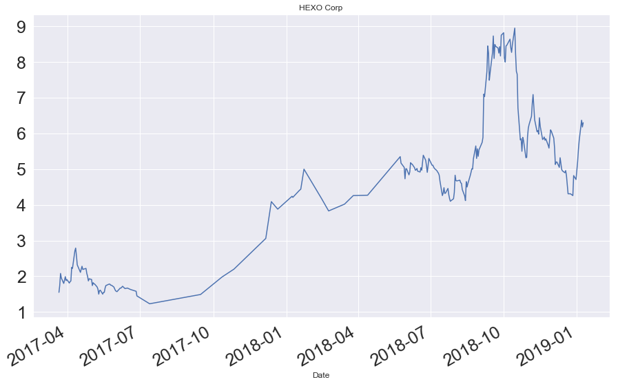

```python
HEXO['Adj Close']['2017':].plot(figsize=(15,9), title='HEXO Corp', fontsize=25)
```

```python
bottom_30 = pd.read_csv('./bottom30.csv')
```

# Summary Information on the bottom 30% of the Canadian Marijuana Index

```python
bottom_30.fillna('-')
```

|  | Name | Market Cap | Bloomberg Description | CEO | CFO |
| --- | --- | --- | --- | --- | --- |
| 0 | CannTrust Holdings Inc. | $762,943,000 | https://www.bloomberg.com/quote/TRST:CN | - | - |
| 1 | OrganiGram Holdings Inc | $732,040,000 | https://www.bloomberg.com/quote/OGI:CN | - | https://www.linkedin.com/in/paolo-deluca/ |
| 2 | The Green Organic Dutchman | $681,443,000 | https://www.bloomberg.com/quote/TGOD:CN | https://www.linkedin.com/in/brianathaide/ | https://www.linkedin.com/in/sean-bovingdon-899... |
| 3 | Canopy Rivers Inc. | $608,000,000 | https://www.bloomberg.com/quote/RIV:CN | - | https://www.linkedin.com/in/eddie-lucarelli-a4... |
| 4 | TerrAscend Corp. | $548,670,000 | https://www.bloomberg.com/quote/TER:CN | https://www.linkedin.com/in/michael-nashat-120... | - |
| 5 | Auxly Cannabis Group Inc. | $507,960,000 | https://www.bloomberg.com/quote/XLY:CN | - | - |
| 6 | The Supreme Cannabis Company Inc. | $478,140,000 | https://www.bloomberg.com/quote/FIRE:CN | - | https://www.linkedin.com/in/dimitre-naoumov-cp... |
| 7 | Emerald Health Therapeutics Inc. | $429,930,000 | https://www.bloomberg.com/quote/EMH:CN | https://www.linkedin.com/in/bin-huang-6b53948/ | - |
| 8 | Namaste Technologies Inc. | $389,870,000 | https://www.bloomberg.com/quote/N:CN | https://www.linkedin.com/in/sean-dollinger-889... | - |
| 9 | Vivo Cannabis Inc. | $256,490,000 | https://www.bloomberg.com/quote/VIVO:CN | https://www.linkedin.com/in/barryfishman/ | https://www.linkedin.com/in/michael-bumby-2408... |
| 10 | Wayland Group | $237,440,000 | https://www.bloomberg.com/quote/WAYL:CN | https://www.linkedin.com/in/ben-ward-740bb427/ | - |
| 11 | Newstrike Brands Ltd | $230,987,000 | https://www.bloomberg.com/quote/HIP:CN | https://www.linkedin.com/in/jay-wilgar-49894820/ | - |
| 12 | Aphria Inc | $202,000,000 | https://www.bloomberg.com/quote/APHA:CN | https://www.linkedin.com/in/vicneufeld/ | - |
| 13 | Sunniva Inc - Ordinary Shares | $183,580,000 | https://www.bloomberg.com/quote/SNN:CN | https://www.linkedin.com/in/leith-pedersen-768... | - |
| 14 | Isodiol International Inc. | $66,810,000 | https://www.bloomberg.com/quote/ISOL:CN | https://www.linkedin.com/in/marcos-agramont-49... | - |